# 강남 3구는 안전한가?

- 강남3구의 주민들이 자신들이 거주하는 구의 체감 안전도를 높게 생각한다는 기사를 확인해 보도록 한다
- 기사 원문 http://news1.kr/articles/?1911504
- Matplotlib의 heatmap 등을 그릴때 cmap의 디폴트 설정이 변경되어 heatmap 등에서 cmap을 적용할 때 옵션을 잡아주어야 교재와 동일한 효과가 나타난다. (소스코드에 모두 반영됨)
- Folium이 0.4.0으로 버전업 되면서 choropleth 명령에서 geo_str 옵션명이 geo_data 옵션명으로 변경됨. (소스코드에 모두 반영)
- Folium이 0.4.0으로 버전업 되면서 circle marker 적용할때, fill=True 옵션을 반듯이 사용해야 함. (소스코드에 모두 반영)
- googleMaps라이브러리 설치 해애주어야 한다. pip install googlemaps
- foluim설치 해주어야 한다. pip install folium

# 데이터 정리하기

- 필요한 모듈을 import한다.

```python
import numpy as np
import pandas as pd
```

- 받은 데이터(csv) 파일을 읽는다, 콤마(,)로 천단위가 구분되어 있고, 한글 엔코딩은 **euc-kr**이다
- 교재에서 접근하는 방식으로 데이터를 얻으로 가면 교재 집필하던 때와 데이터의 형식이 변경되어 있다.
- 지금은 데이터를 얻는 것이 실제 데이터라는 것에 대한 증명일 뿐이므로, 해당 데이터를 Github에서 배포하는 데이터를 다운받는 것으로 한다.

```python
crime_anal_police = pd.read_csv('../data/02. crime_in_Seoul.csv', thousands=',',
                                encoding='euc-kr')
crime_anal_police.head()
```

|  | 관서명 | 살인 발생 | 살인 검거 | 강도 발생 | 강도 검거 | 강간 발생 | 강간 검거 | 절도 발생 | 절도 검거 | 폭력 발생 | 폭력 검거 |
| --- | --- | --- | --- | --- | --- | --- | --- | --- | --- | --- | --- |
| 0 | 중부서 | 2 | 2 | 3 | 2 | 105 | 65 | 1395 | 477 | 1355 | 1170 |
| 1 | 종로서 | 3 | 3 | 6 | 5 | 115 | 98 | 1070 | 413 | 1278 | 1070 |
| 2 | 남대문서 | 1 | 0 | 6 | 4 | 65 | 46 | 1153 | 382 | 869 | 794 |
| 3 | 서대문서 | 2 | 2 | 5 | 4 | 154 | 124 | 1812 | 738 | 2056 | 1711 |
| 4 | 혜화서 | 3 | 2 | 5 | 4 | 96 | 63 | 1114 | 424 | 1015 | 861 |

- 구글 맵스를 사용해서 경찰서의 위치(위도, 경도) 정보를 받아온다

```python
import googlemaps
```

```python
gmaps_key = "AIzaSyB_id_BNZoD_1_QSXufdkIPD7muNK9Wjlc" # 자신의 key를 사용합니다.
gmaps = googlemaps.Client(key=gmaps_key)
```

```python
gmaps.geocode('서울중부경찰서', language='ko')
```

```
[{'address_components': [{'long_name': '２７',
    'short_name': '２７',
    'types': ['premise']},
   {'long_name': '수표로',
    'short_name': '수표로',
    'types': ['political', 'sublocality', 'sublocality_level_4']},
   {'long_name': '을지로동',
    'short_name': '을지로동',
    'types': ['political', 'sublocality', 'sublocality_level_2']},
   {'long_name': '중구',
    'short_name': '중구',
    'types': ['political', 'sublocality', 'sublocality_level_1']},
   {'long_name': '서울특별시',
    'short_name': '서울특별시',
    'types': ['administrative_area_level_1', 'political']},
   {'long_name': '대한민국',
    'short_name': 'KR',
    'types': ['country', 'political']},
   {'long_name': '100-032',
    'short_name': '100-032',
    'types': ['postal_code']}],
  'formatted_address': '대한민국 서울특별시 중구 을지로동 수표로 27',
  'geometry': {'location': {'lat': 37.5636465, 'lng': 126.9895796},
   'location_type': 'ROOFTOP',
   'viewport': {'northeast': {'lat': 37.56499548029149,
     'lng': 126.9909285802915},
    'southwest': {'lat': 37.56229751970849, 'lng': 126.9882306197085}}},
  'place_id': 'ChIJc-9q5uSifDURLhQmr5wkXmc',
  'plus_code': {'compound_code': 'HX7Q+FR 대한민국 서울특별시',
   'global_code': '8Q98HX7Q+FR'},
  'types': ['establishment', 'point_of_interest', 'police']}]
```

```python
station_name = []

for name in crime_anal_police['관서명']:
    station_name.append('서울' + str(name[:-1]) + '경찰서')

station_name
```

```
['서울중부경찰서',
 '서울종로경찰서',
 '서울남대문경찰서',
 '서울서대문경찰서',
 '서울혜화경찰서',
 '서울용산경찰서',
 '서울성북경찰서',
 '서울동대문경찰서',
 '서울마포경찰서',
 '서울영등포경찰서',
 '서울성동경찰서',
 '서울동작경찰서',
 '서울광진경찰서',
 '서울서부경찰서',
 '서울강북경찰서',
 '서울금천경찰서',
 '서울중랑경찰서',
 '서울강남경찰서',
 '서울관악경찰서',
 '서울강서경찰서',
 '서울강동경찰서',
 '서울종암경찰서',
 '서울구로경찰서',
 '서울서초경찰서',
 '서울양천경찰서',
 '서울송파경찰서',
 '서울노원경찰서',
 '서울방배경찰서',
 '서울은평경찰서',
 '서울도봉경찰서',
 '서울수서경찰서']
```

```python
station_addreess = []
station_lat = []
station_lng = []

for name in station_name:
    tmp = gmaps.geocode(name, language='ko')
    station_addreess.append(tmp[0].get("formatted_address"))

    tmp_loc = tmp[0].get("geometry")

    station_lat.append(tmp_loc['location']['lat'])
    station_lng.append(tmp_loc['location']['lng'])

    print(name + '-->' + tmp[0].get("formatted_address"))
```

```
서울중부경찰서-->대한민국 서울특별시 중구 을지로동 수표로 27
서울종로경찰서-->대한민국 서울특별시 종로구 종로1.2.3.4가동 율곡로 46
서울남대문경찰서-->대한민국 서울특별시 중구 회현동 한강대로 410
서울서대문경찰서-->대한민국 서울특별시 서대문구 충현동 통일로 113
서울혜화경찰서-->대한민국 서울특별시 종로구 인의동 창경궁로 112-16
서울용산경찰서-->대한민국 서울특별시 용산구 원효로1가 백범로 329
서울성북경찰서-->대한민국 서울특별시 성북구 삼선동5가 301
서울동대문경찰서-->대한민국 서울특별시 동대문구 청량리동 약령시로21길 29
서울마포경찰서-->대한민국 서울특별시 마포구 아현동 618-1
서울영등포경찰서-->대한민국 서울특별시 영등포구 영등포동 영등포로46길 14
서울성동경찰서-->대한민국 서울특별시 성동구 행당동 왕십리광장로 9
서울동작경찰서-->대한민국 서울특별시 동작구 노량진1동 노량진로 148
서울광진경찰서-->대한민국 서울특별시 광진구 구의1동 자양로 167
서울서부경찰서-->대한민국 서울특별시 은평구 대조동 통일로 757
서울강북경찰서-->대한민국 서울특별시 강북구 번1동 오패산로 406
서울금천경찰서-->대한민국 서울특별시 금천구 시흥동 190
서울중랑경찰서-->대한민국 서울특별시 중랑구 신내1동 신내역로3길 40-10
서울강남경찰서-->대한민국 서울특별시 강남구 대치동 998
서울관악경찰서-->대한민국 서울특별시 관악구 봉천동
서울강서경찰서-->대한민국 서울특별시 양천구 신월동 화곡로 73
서울강동경찰서-->대한민국 서울특별시 강동구 성내1동 성내로 57
서울종암경찰서-->대한민국 서울특별시 성북구 종암동 종암로 135
서울구로경찰서-->대한민국 서울특별시 구로구 가마산로 235
서울서초경찰서-->대한민국 서울특별시 서초구 서초3동 반포대로 179
서울양천경찰서-->대한민국 서울특별시 양천구 신정6동 목동동로 99
서울송파경찰서-->대한민국 서울특별시 송파구 가락본동 9
서울노원경찰서-->대한민국 서울특별시 노원구 하계동 노원로 283
서울방배경찰서-->대한민국 서울특별시 서초구 방배본동 동작대로 204
서울은평경찰서-->대한민국 서울특별시 은평구 불광동 연서로 365
서울도봉경찰서-->대한민국 서울특별시 도봉구 창4동 노해로 403
서울수서경찰서-->대한민국 서울특별시 강남구 개포동 개포로 617
```

```python
station_addreess
```

```
['대한민국 서울특별시 중구 을지로동 수표로 27',
 '대한민국 서울특별시 종로구 종로1.2.3.4가동 율곡로 46',
 '대한민국 서울특별시 중구 회현동 한강대로 410',
 '대한민국 서울특별시 서대문구 충현동 통일로 113',
 '대한민국 서울특별시 종로구 인의동 창경궁로 112-16',
 '대한민국 서울특별시 용산구 원효로1가 백범로 329',
 '대한민국 서울특별시 성북구 삼선동5가 301',
 '대한민국 서울특별시 동대문구 청량리동 약령시로21길 29',
 '대한민국 서울특별시 마포구 아현동 618-1',
 '대한민국 서울특별시 영등포구 영등포동 영등포로46길 14',
 '대한민국 서울특별시 성동구 행당동 왕십리광장로 9',
 '대한민국 서울특별시 동작구 노량진1동 노량진로 148',
 '대한민국 서울특별시 광진구 구의1동 자양로 167',
 '대한민국 서울특별시 은평구 대조동 통일로 757',
 '대한민국 서울특별시 강북구 번1동 오패산로 406',
 '대한민국 서울특별시 금천구 시흥동 190',
 '대한민국 서울특별시 중랑구 신내1동 신내역로3길 40-10',
 '대한민국 서울특별시 강남구 대치동 998',
 '대한민국 서울특별시 관악구 봉천동',
 '대한민국 서울특별시 양천구 신월동 화곡로 73',
 '대한민국 서울특별시 강동구 성내1동 성내로 57',
 '대한민국 서울특별시 성북구 종암동 종암로 135',
 '대한민국 서울특별시 구로구 가마산로 235',
 '대한민국 서울특별시 서초구 서초3동 반포대로 179',
 '대한민국 서울특별시 양천구 신정6동 목동동로 99',
 '대한민국 서울특별시 송파구 가락본동 9',
 '대한민국 서울특별시 노원구 하계동 노원로 283',
 '대한민국 서울특별시 서초구 방배본동 동작대로 204',
 '대한민국 서울특별시 은평구 불광동 연서로 365',
 '대한민국 서울특별시 도봉구 창4동 노해로 403',
 '대한민국 서울특별시 강남구 개포동 개포로 617']
```

```python
station_lat
```

```
[37.5636465,
 37.5755578,
 37.5547584,
 37.5647848,
 37.5718529,
 37.5387099,
 37.5897482,
 37.58506149999999,
 37.550814,
 37.5179839,
 37.5617309,
 37.5130866,
 37.542873,
 37.6128611,
 37.63730390000001,
 37.4568722,
 37.618692,
 37.5094352,
 37.4743789,
 37.5397827,
 37.528511,
 37.6020592,
 37.494931,
 37.4956054,
 37.5165667,
 37.5019065,
 37.6423605,
 37.4945959,
 37.6283597,
 37.6533589,
 37.49349]
```

```python
station_lng
```

```
[126.9895796,
 126.9848674,
 126.9734981,
 126.9667762,
 126.9989143,
 126.9659183,
 127.0161353,
 127.0457679,
 126.954028,
 126.9075056,
 127.0363806,
 126.9428498,
 127.083821,
 126.9274951,
 127.0273399,
 126.8970429,
 127.1047136,
 127.0669578,
 126.9509748,
 126.8299968,
 127.1268224,
 127.0321577,
 126.886731,
 127.0052504,
 126.8656763,
 127.1271513,
 127.0714027,
 126.9831279,
 126.9287226,
 127.052682,
 127.0772119]
```

```python
gu_name = []

for name in station_addreess:
    tmp = name.split()

    tmp_gu = [gu for gu in tmp if gu[-1] == '구'][0]

    gu_name.append(tmp_gu)

crime_anal_police['구별'] = gu_name
crime_anal_police.head()
```

|  | 관서명 | 살인 발생 | 살인 검거 | 강도 발생 | 강도 검거 | 강간 발생 | 강간 검거 | 절도 발생 | 절도 검거 | 폭력 발생 | 폭력 검거 | 구별 |
| --- | --- | --- | --- | --- | --- | --- | --- | --- | --- | --- | --- | --- |
| 0 | 중부서 | 2 | 2 | 3 | 2 | 105 | 65 | 1395 | 477 | 1355 | 1170 | 중구 |
| 1 | 종로서 | 3 | 3 | 6 | 5 | 115 | 98 | 1070 | 413 | 1278 | 1070 | 종로구 |
| 2 | 남대문서 | 1 | 0 | 6 | 4 | 65 | 46 | 1153 | 382 | 869 | 794 | 중구 |
| 3 | 서대문서 | 2 | 2 | 5 | 4 | 154 | 124 | 1812 | 738 | 2056 | 1711 | 서대문구 |
| 4 | 혜화서 | 3 | 2 | 5 | 4 | 96 | 63 | 1114 | 424 | 1015 | 861 | 종로구 |

```python
crime_anal_police[crime_anal_police['관서명']=='금천서']
```

|  | 관서명 | 살인 발생 | 살인 검거 | 강도 발생 | 강도 검거 | 강간 발생 | 강간 검거 | 절도 발생 | 절도 검거 | 폭력 발생 | 폭력 검거 | 구별 |
| --- | --- | --- | --- | --- | --- | --- | --- | --- | --- | --- | --- | --- |
| 15 | 금천서 | 3 | 4 | 6 | 6 | 151 | 122 | 1567 | 888 | 2054 | 1776 | 금천구 |

```python
crime_anal_police.loc[crime_anal_police['관서명']=='금천서', ['구별']] = '금천구'
crime_anal_police[crime_anal_police['관서명']=='금천서']
```

|  | 관서명 | 살인 발생 | 살인 검거 | 강도 발생 | 강도 검거 | 강간 발생 | 강간 검거 | 절도 발생 | 절도 검거 | 폭력 발생 | 폭력 검거 | 구별 |
| --- | --- | --- | --- | --- | --- | --- | --- | --- | --- | --- | --- | --- |
| 15 | 금천서 | 3 | 4 | 6 | 6 | 151 | 122 | 1567 | 888 | 2054 | 1776 | 금천구 |

```python
crime_anal_police.to_csv('../data/02. crime_in_Seoul_include_gu_name.csv',
                         sep=',', encoding='utf-8')
```

```python
crime_anal_police.head()
```

|  | 관서명 | 살인 발생 | 살인 검거 | 강도 발생 | 강도 검거 | 강간 발생 | 강간 검거 | 절도 발생 | 절도 검거 | 폭력 발생 | 폭력 검거 | 구별 |
| --- | --- | --- | --- | --- | --- | --- | --- | --- | --- | --- | --- | --- |
| 0 | 중부서 | 2 | 2 | 3 | 2 | 105 | 65 | 1395 | 477 | 1355 | 1170 | 중구 |
| 1 | 종로서 | 3 | 3 | 6 | 5 | 115 | 98 | 1070 | 413 | 1278 | 1070 | 종로구 |
| 2 | 남대문서 | 1 | 0 | 6 | 4 | 65 | 46 | 1153 | 382 | 869 | 794 | 중구 |
| 3 | 서대문서 | 2 | 2 | 5 | 4 | 154 | 124 | 1812 | 738 | 2056 | 1711 | 서대문구 |
| 4 | 혜화서 | 3 | 2 | 5 | 4 | 96 | 63 | 1114 | 424 | 1015 | 861 | 종로구 |

# pandas의 pivot_table 익히기

```python
import pandas as pd
import numpy as np
```

```python
df = pd.read_excel("../data/02. sales-funnel.xlsx")
df.head()
```

|  | Account | Name | Rep | Manager | Product | Quantity | Price | Status |
| --- | --- | --- | --- | --- | --- | --- | --- | --- |
| 0 | 714466 | Trantow-Barrows | Craig Booker | Debra Henley | CPU | 1 | 30000 | presented |
| 1 | 714466 | Trantow-Barrows | Craig Booker | Debra Henley | Software | 1 | 10000 | presented |
| 2 | 714466 | Trantow-Barrows | Craig Booker | Debra Henley | Maintenance | 2 | 5000 | pending |
| 3 | 737550 | Fritsch, Russel and Anderson | Craig Booker | Debra Henley | CPU | 1 | 35000 | declined |
| 4 | 146832 | Kiehn-Spinka | Daniel Hilton | Debra Henley | CPU | 2 | 65000 | won |

```python
pd.pivot_table(df,index=["Name"])
```

| Name | Account | Price | Quantity |
| --- | --- | --- | --- |
| Barton LLC | 740150 | 35000 | 1.000000 |
| Fritsch, Russel and Anderson | 737550 | 35000 | 1.000000 |
| Herman LLC | 141962 | 65000 | 2.000000 |
| Jerde-Hilpert | 412290 | 5000 | 2.000000 |
| Kassulke, Ondricka and Metz | 307599 | 7000 | 3.000000 |
| Keeling LLC | 688981 | 100000 | 5.000000 |
| Kiehn-Spinka | 146832 | 65000 | 2.000000 |
| Koepp Ltd | 729833 | 35000 | 2.000000 |
| Kulas Inc | 218895 | 25000 | 1.500000 |
| Purdy-Kunde | 163416 | 30000 | 1.000000 |
| Stokes LLC | 239344 | 7500 | 1.000000 |
| Trantow-Barrows | 714466 | 15000 | 1.333333 |

```python
pd.pivot_table(df,index=["Name","Rep","Manager"])
```

| Name | Rep | Manager | Account | Price | Quantity |
| --- | --- | --- | --- | --- | --- |
| Barton LLC | John Smith | Debra Henley | 740150 | 35000 | 1.000000 |
| Fritsch, Russel and Anderson | Craig Booker | Debra Henley | 737550 | 35000 | 1.000000 |
| Herman LLC | Cedric Moss | Fred Anderson | 141962 | 65000 | 2.000000 |
| Jerde-Hilpert | John Smith | Debra Henley | 412290 | 5000 | 2.000000 |
| Kassulke, Ondricka and Metz | Wendy Yule | Fred Anderson | 307599 | 7000 | 3.000000 |
| Keeling LLC | Wendy Yule | Fred Anderson | 688981 | 100000 | 5.000000 |
| Kiehn-Spinka | Daniel Hilton | Debra Henley | 146832 | 65000 | 2.000000 |
| Koepp Ltd | Wendy Yule | Fred Anderson | 729833 | 35000 | 2.000000 |
| Kulas Inc | Daniel Hilton | Debra Henley | 218895 | 25000 | 1.500000 |
| Purdy-Kunde | Cedric Moss | Fred Anderson | 163416 | 30000 | 1.000000 |
| Stokes LLC | Cedric Moss | Fred Anderson | 239344 | 7500 | 1.000000 |
| Trantow-Barrows | Craig Booker | Debra Henley | 714466 | 15000 | 1.333333 |

```python
pd.pivot_table(df,index=["Manager","Rep"])
```

| Manager | Rep | Account | Price | Quantity |
| --- | --- | --- | --- | --- |
| Debra Henley | Craig Booker | 720237.0 | 20000.000000 | 1.250000 |
|  | Daniel Hilton | 194874.0 | 38333.333333 | 1.666667 |
|  | John Smith | 576220.0 | 20000.000000 | 1.500000 |
| Fred Anderson | Cedric Moss | 196016.5 | 27500.000000 | 1.250000 |
|  | Wendy Yule | 614061.5 | 44250.000000 | 3.000000 |

```python
pd.pivot_table(df,index=["Manager","Rep"],values=["Price"])
```

| Manager | Rep | Price |
| --- | --- | --- |
| Debra Henley | Craig Booker | 20000.000000 |
|  | Daniel Hilton | 38333.333333 |
|  | John Smith | 20000.000000 |
| Fred Anderson | Cedric Moss | 27500.000000 |
|  | Wendy Yule | 44250.000000 |

```python
pd.pivot_table(df,index=["Manager","Rep"],values=["Price"],aggfunc=np.sum)
```

| Manager | Rep | Price |
| --- | --- | --- |
| Debra Henley | Craig Booker | 80000 |
|  | Daniel Hilton | 115000 |
|  | John Smith | 40000 |
| Fred Anderson | Cedric Moss | 110000 |
|  | Wendy Yule | 177000 |

```python
pd.pivot_table(df,index=["Manager","Rep"],values=["Price"],aggfunc=[np.mean,len])
```

| Manager | Rep | mean Price | len Price |
| --- | --- | --- | --- |
| Debra Henley | Craig Booker | 20000.000000 | 4 |
|  | Daniel Hilton | 38333.333333 | 3 |
|  | John Smith | 20000.000000 | 2 |
| Fred Anderson | Cedric Moss | 27500.000000 | 4 |
|  | Wendy Yule | 44250.000000 | 4 |

```python
pd.pivot_table(df,index=["Manager","Rep"],values=["Price"],
               columns=["Product"],aggfunc=[np.sum])
```

| Manager | Product Rep | sum Price CPU | sum Price Maintenance | sum Price Monitor | sum Price Software |
| --- | --- | --- | --- | --- | --- |
| Debra Henley | Craig Booker | 65000.0 | 5000.0 | NaN | 10000.0 |
|  | Daniel Hilton | 105000.0 | NaN | NaN | 10000.0 |
|  | John Smith | 35000.0 | 5000.0 | NaN | NaN |
| Fred Anderson | Cedric Moss | 95000.0 | 5000.0 | NaN | 10000.0 |
|  | Wendy Yule | 165000.0 | 7000.0 | 5000.0 | NaN |

```python
pd.pivot_table(df,index=["Manager","Rep"],values=["Price"],
               columns=["Product"],aggfunc=[np.sum],fill_value=0)
```

| Manager | Product Rep | sum Price CPU | sum Price Maintenance | sum Price Monitor | sum Price Software |
| --- | --- | --- | --- | --- | --- |
| Debra Henley | Craig Booker | 65000 | 5000 | 0 | 10000 |
|  | Daniel Hilton | 105000 | 0 | 0 | 10000 |
|  | John Smith | 35000 | 5000 | 0 | 0 |
| Fred Anderson | Cedric Moss | 95000 | 5000 | 0 | 10000 |
|  | Wendy Yule | 165000 | 7000 | 5000 | 0 |

```python
pd.pivot_table(df,index=["Manager","Rep","Product"],
               values=["Price","Quantity"],aggfunc=[np.sum],fill_value=0)
```

| Manager | Rep | Product | sum Price | sum Quantity |
| --- | --- | --- | --- | --- |
| Debra Henley | Craig Booker | CPU | 65000 | 2 |
|  |  | Maintenance | 5000 | 2 |
|  |  | Software | 10000 | 1 |
|  | Daniel Hilton | CPU | 105000 | 4 |
|  |  | Software | 10000 | 1 |
|  | John Smith | CPU | 35000 | 1 |
|  |  | Maintenance | 5000 | 2 |
| Fred Anderson | Cedric Moss | CPU | 95000 | 3 |
|  |  | Maintenance | 5000 | 1 |
|  |  | Software | 10000 | 1 |
|  | Wendy Yule | CPU | 165000 | 7 |
|  |  | Maintenance | 7000 | 3 |
|  |  | Monitor | 5000 | 2 |

```python
pd.pivot_table(df,index=["Manager","Rep","Product"],
               values=["Price","Quantity"],
               aggfunc=[np.sum,np.mean],fill_value=0,margins=True)
```

| Manager | Rep | Product | sum Price | sum Quantity | mean Price | mean Quantity |
| --- | --- | --- | --- | --- | --- | --- |
| Debra Henley | Craig Booker | CPU | 65000 | 2 | 32500 | 1.000000 |
|  |  | Maintenance | 5000 | 2 | 5000 | 2.000000 |
|  |  | Software | 10000 | 1 | 10000 | 1.000000 |
|  | Daniel Hilton | CPU | 105000 | 4 | 52500 | 2.000000 |
|  |  | Software | 10000 | 1 | 10000 | 1.000000 |
|  | John Smith | CPU | 35000 | 1 | 35000 | 1.000000 |
|  |  | Maintenance | 5000 | 2 | 5000 | 2.000000 |
| Fred Anderson | Cedric Moss | CPU | 95000 | 3 | 47500 | 1.500000 |
|  |  | Maintenance | 5000 | 1 | 5000 | 1.000000 |
|  |  | Software | 10000 | 1 | 10000 | 1.000000 |
|  | Wendy Yule | CPU | 165000 | 7 | 82500 | 3.500000 |
|  |  | Maintenance | 7000 | 3 | 7000 | 3.000000 |
|  |  | Monitor | 5000 | 2 | 5000 | 2.000000 |
| All |  |  | 522000 | 30 | 30705 | 1.764706 |

# 범죄 데이터 구별로 정리하기

```python
crime_anal_raw = pd.read_csv('../data/02. crime_in_Seoul_include_gu_name.csv',
                             encoding='utf-8')
crime_anal_raw.head()
```

|  | Unnamed: 0 | 관서명 | 살인 발생 | 살인 검거 | 강도 발생 | 강도 검거 | 강간 발생 | 강간 검거 | 절도 발생 | 절도 검거 | 폭력 발생 | 폭력 검거 | 구별 |
| --- | --- | --- | --- | --- | --- | --- | --- | --- | --- | --- | --- | --- | --- |
| 0 | 0 | 중부서 | 2 | 2 | 3 | 2 | 105 | 65 | 1395 | 477 | 1355 | 1170 | 중구 |
| 1 | 1 | 종로서 | 3 | 3 | 6 | 5 | 115 | 98 | 1070 | 413 | 1278 | 1070 | 종로구 |
| 2 | 2 | 남대문서 | 1 | 0 | 6 | 4 | 65 | 46 | 1153 | 382 | 869 | 794 | 중구 |
| 3 | 3 | 서대문서 | 2 | 2 | 5 | 4 | 154 | 124 | 1812 | 738 | 2056 | 1711 | 서대문구 |
| 4 | 4 | 혜화서 | 3 | 2 | 5 | 4 | 96 | 63 | 1114 | 424 | 1015 | 861 | 종로구 |

```python
crime_anal_raw = pd.read_csv('../data/02. crime_in_Seoul_include_gu_name.csv',
                             encoding='utf-8', index_col=0)

crime_anal = pd.pivot_table(crime_anal_raw, index='구별', aggfunc=np.sum)
crime_anal.head()
```

| 구별 | 강간 검거 | 강간 발생 | 강도 검거 | 강도 발생 | 살인 검거 | 살인 발생 | 절도 검거 | 절도 발생 | 폭력 검거 | 폭력 발생 |
| --- | --- | --- | --- | --- | --- | --- | --- | --- | --- | --- |
| 강남구 | 349 | 449 | 18 | 21 | 10 | 13 | 1650 | 3850 | 3705 | 4284 |
| 강동구 | 123 | 156 | 8 | 6 | 3 | 4 | 789 | 2366 | 2248 | 2712 |
| 강북구 | 126 | 153 | 13 | 14 | 8 | 7 | 618 | 1434 | 2348 | 2649 |
| 관악구 | 221 | 320 | 14 | 12 | 8 | 9 | 827 | 2706 | 2642 | 3298 |
| 광진구 | 220 | 240 | 26 | 14 | 4 | 4 | 1277 | 3026 | 2180 | 2625 |

```python
crime_anal['강간검거율'] = crime_anal['강간 검거']/crime_anal['강간 발생']*100
crime_anal['강도검거율'] = crime_anal['강도 검거']/crime_anal['강도 발생']*100
crime_anal['살인검거율'] = crime_anal['살인 검거']/crime_anal['살인 발생']*100
crime_anal['절도검거율'] = crime_anal['절도 검거']/crime_anal['절도 발생']*100
crime_anal['폭력검거율'] = crime_anal['폭력 검거']/crime_anal['폭력 발생']*100

del crime_anal['강간 검거']
del crime_anal['강도 검거']
del crime_anal['살인 검거']
del crime_anal['절도 검거']
del crime_anal['폭력 검거']

crime_anal.head()
```

| 구별 | 강간 발생 | 강도 발생 | 살인 발생 | 절도 발생 | 폭력 발생 | 강간검거율 | 강도검거율 | 살인검거율 | 절도검거율 | 폭력검거율 |
| --- | --- | --- | --- | --- | --- | --- | --- | --- | --- | --- |
| 강남구 | 449 | 21 | 13 | 3850 | 4284 | 77.728285 | 85.714286 | 76.923077 | 42.857143 | 86.484594 |
| 강동구 | 156 | 6 | 4 | 2366 | 2712 | 78.846154 | 133.333333 | 75.000000 | 33.347422 | 82.890855 |
| 강북구 | 153 | 14 | 7 | 1434 | 2649 | 82.352941 | 92.857143 | 114.285714 | 43.096234 | 88.637222 |
| 관악구 | 320 | 12 | 9 | 2706 | 3298 | 69.062500 | 116.666667 | 88.888889 | 30.561715 | 80.109157 |
| 광진구 | 240 | 14 | 4 | 3026 | 2625 | 91.666667 | 185.714286 | 100.000000 | 42.200925 | 83.047619 |

```python
con_list = ['강간검거율', '강도검거율', '살인검거율', '절도검거율', '폭력검거율']

for column in con_list:
    crime_anal.loc[crime_anal[column] > 100, column] = 100

crime_anal.head()
```

| 구별 | 강간 발생 | 강도 발생 | 살인 발생 | 절도 발생 | 폭력 발생 | 강간검거율 | 강도검거율 | 살인검거율 | 절도검거율 | 폭력검거율 |
| --- | --- | --- | --- | --- | --- | --- | --- | --- | --- | --- |
| 강남구 | 449 | 21 | 13 | 3850 | 4284 | 77.728285 | 85.714286 | 76.923077 | 42.857143 | 86.484594 |
| 강동구 | 156 | 6 | 4 | 2366 | 2712 | 78.846154 | 100.000000 | 75.000000 | 33.347422 | 82.890855 |
| 강북구 | 153 | 14 | 7 | 1434 | 2649 | 82.352941 | 92.857143 | 100.000000 | 43.096234 | 88.637222 |
| 관악구 | 320 | 12 | 9 | 2706 | 3298 | 69.062500 | 100.000000 | 88.888889 | 30.561715 | 80.109157 |
| 광진구 | 240 | 14 | 4 | 3026 | 2625 | 91.666667 | 100.000000 | 100.000000 | 42.200925 | 83.047619 |

```python
crime_anal.rename(columns = {'강간 발생':'강간',
                             '강도 발생':'강도',
                             '살인 발생':'살인',
                             '절도 발생':'절도',
                             '폭력 발생':'폭력'}, inplace=True)
crime_anal.head()
```

| 구별 | 강간 | 강도 | 살인 | 절도 | 폭력 | 강간검거율 | 강도검거율 | 살인검거율 | 절도검거율 | 폭력검거율 |
| --- | --- | --- | --- | --- | --- | --- | --- | --- | --- | --- |
| 강남구 | 449 | 21 | 13 | 3850 | 4284 | 77.728285 | 85.714286 | 76.923077 | 42.857143 | 86.484594 |
| 강동구 | 156 | 6 | 4 | 2366 | 2712 | 78.846154 | 100.000000 | 75.000000 | 33.347422 | 82.890855 |
| 강북구 | 153 | 14 | 7 | 1434 | 2649 | 82.352941 | 92.857143 | 100.000000 | 43.096234 | 88.637222 |
| 관악구 | 320 | 12 | 9 | 2706 | 3298 | 69.062500 | 100.000000 | 88.888889 | 30.561715 | 80.109157 |
| 광진구 | 240 | 14 | 4 | 3026 | 2625 | 91.666667 | 100.000000 | 100.000000 | 42.200925 | 83.047619 |

```python
from sklearn import preprocessing

col = ['강간', '강도', '살인', '절도', '폭력']

x = crime_anal[col].values
min_max_scaler = preprocessing.MinMaxScaler()

x_scaled = min_max_scaler.fit_transform(x.astype(float))
crime_anal_norm = pd.DataFrame(x_scaled, columns = col, index = crime_anal.index)

col2 = ['강간검거율', '강도검거율', '살인검거율', '절도검거율', '폭력검거율']
crime_anal_norm[col2] = crime_anal[col2]
crime_anal_norm.head()
```

| 구별 | 강간 | 강도 | 살인 | 절도 | 폭력 | 강간검거율 | 강도검거율 | 살인검거율 | 절도검거율 | 폭력검거율 |
| --- | --- | --- | --- | --- | --- | --- | --- | --- | --- | --- |
| 강남구 | 1.000000 | 0.941176 | 0.916667 | 0.953472 | 0.661386 | 77.728285 | 85.714286 | 76.923077 | 42.857143 | 86.484594 |
| 강동구 | 0.155620 | 0.058824 | 0.166667 | 0.445775 | 0.289667 | 78.846154 | 100.000000 | 75.000000 | 33.347422 | 82.890855 |
| 강북구 | 0.146974 | 0.529412 | 0.416667 | 0.126924 | 0.274769 | 82.352941 | 92.857143 | 100.000000 | 43.096234 | 88.637222 |
| 관악구 | 0.628242 | 0.411765 | 0.583333 | 0.562094 | 0.428234 | 69.062500 | 100.000000 | 88.888889 | 30.561715 | 80.109157 |
| 광진구 | 0.397695 | 0.529412 | 0.166667 | 0.671570 | 0.269094 | 91.666667 | 100.000000 | 100.000000 | 42.200925 | 83.047619 |

```python
result_CCTV = pd.read_csv('../data/01. CCTV_result.csv', encoding='UTF-8',
                          index_col='구별')
crime_anal_norm[['인구수', 'CCTV']] = result_CCTV[['인구수', '소계']]
crime_anal_norm.head()
```

| 구별 | 강간 | 강도 | 살인 | 절도 | 폭력 | 강간검거율 | 강도검거율 | 살인검거율 | 절도검거율 | 폭력검거율 | 인구수 | CCTV |
| --- | --- | --- | --- | --- | --- | --- | --- | --- | --- | --- | --- | --- |
| 강남구 | 1.000000 | 0.941176 | 0.916667 | 0.953472 | 0.661386 | 77.728285 | 85.714286 | 76.923077 | 42.857143 | 86.484594 | 570500.0 | 2780 |
| 강동구 | 0.155620 | 0.058824 | 0.166667 | 0.445775 | 0.289667 | 78.846154 | 100.000000 | 75.000000 | 33.347422 | 82.890855 | 453233.0 | 773 |
| 강북구 | 0.146974 | 0.529412 | 0.416667 | 0.126924 | 0.274769 | 82.352941 | 92.857143 | 100.000000 | 43.096234 | 88.637222 | 330192.0 | 748 |
| 관악구 | 0.628242 | 0.411765 | 0.583333 | 0.562094 | 0.428234 | 69.062500 | 100.000000 | 88.888889 | 30.561715 | 80.109157 | 525515.0 | 1496 |
| 광진구 | 0.397695 | 0.529412 | 0.166667 | 0.671570 | 0.269094 | 91.666667 | 100.000000 | 100.000000 | 42.200925 | 83.047619 | 372164.0 | 707 |

```python
col = ['강간','강도','살인','절도','폭력']
crime_anal_norm['범죄'] = np.sum(crime_anal_norm[col], axis=1)
crime_anal_norm.head()
```

| 구별 | 강간 | 강도 | 살인 | 절도 | 폭력 | 강간검거율 | 강도검거율 | 살인검거율 | 절도검거율 | 폭력검거율 | 인구수 | CCTV | 범죄 |
| --- | --- | --- | --- | --- | --- | --- | --- | --- | --- | --- | --- | --- | --- |
| 강남구 | 1.000000 | 0.941176 | 0.916667 | 0.953472 | 0.661386 | 77.728285 | 85.714286 | 76.923077 | 42.857143 | 86.484594 | 570500.0 | 2780 | 4.472701 |
| 강동구 | 0.155620 | 0.058824 | 0.166667 | 0.445775 | 0.289667 | 78.846154 | 100.000000 | 75.000000 | 33.347422 | 82.890855 | 453233.0 | 773 | 1.116551 |
| 강북구 | 0.146974 | 0.529412 | 0.416667 | 0.126924 | 0.274769 | 82.352941 | 92.857143 | 100.000000 | 43.096234 | 88.637222 | 330192.0 | 748 | 1.494746 |
| 관악구 | 0.628242 | 0.411765 | 0.583333 | 0.562094 | 0.428234 | 69.062500 | 100.000000 | 88.888889 | 30.561715 | 80.109157 | 525515.0 | 1496 | 2.613667 |
| 광진구 | 0.397695 | 0.529412 | 0.166667 | 0.671570 | 0.269094 | 91.666667 | 100.000000 | 100.000000 | 42.200925 | 83.047619 | 372164.0 | 707 | 2.034438 |

```python
col = ['강간검거율','강도검거율','살인검거율','절도검거율','폭력검거율']
crime_anal_norm['검거'] = np.sum(crime_anal_norm[col], axis=1)
crime_anal_norm.head()
```

| 구별 | 강간 | 강도 | 살인 | 절도 | 폭력 | 강간검거율 | 강도검거율 | 살인검거율 | 절도검거율 | 폭력검거율 | 인구수 | CCTV | 범죄 | 검거 |
| --- | --- | --- | --- | --- | --- | --- | --- | --- | --- | --- | --- | --- | --- | --- |
| 강남구 | 1.000000 | 0.941176 | 0.916667 | 0.953472 | 0.661386 | 77.728285 | 85.714286 | 76.923077 | 42.857143 | 86.484594 | 570500.0 | 2780 | 4.472701 | 369.707384 |
| 강동구 | 0.155620 | 0.058824 | 0.166667 | 0.445775 | 0.289667 | 78.846154 | 100.000000 | 75.000000 | 33.347422 | 82.890855 | 453233.0 | 773 | 1.116551 | 370.084431 |
| 강북구 | 0.146974 | 0.529412 | 0.416667 | 0.126924 | 0.274769 | 82.352941 | 92.857143 | 100.000000 | 43.096234 | 88.637222 | 330192.0 | 748 | 1.494746 | 406.943540 |
| 관악구 | 0.628242 | 0.411765 | 0.583333 | 0.562094 | 0.428234 | 69.062500 | 100.000000 | 88.888889 | 30.561715 | 80.109157 | 525515.0 | 1496 | 2.613667 | 368.622261 |
| 광진구 | 0.397695 | 0.529412 | 0.166667 | 0.671570 | 0.269094 | 91.666667 | 100.000000 | 100.000000 | 42.200925 | 83.047619 | 372164.0 | 707 | 2.034438 | 416.915211 |

```python
crime_anal_norm
```

| 구별 | 강간 | 강도 | 살인 | 절도 | 폭력 | 강간검거율 | 강도검거율 | 살인검거율 | 절도검거율 | 폭력검거율 | 인구수 | CCTV | 범죄 | 검거 |
| --- | --- | --- | --- | --- | --- | --- | --- | --- | --- | --- | --- | --- | --- | --- |
| 강남구 | 1.000000 | 0.941176 | 0.916667 | 0.953472 | 0.661386 | 77.728285 | 85.714286 | 76.923077 | 42.857143 | 86.484594 | 570500.0 | 2780 | 4.472701 | 369.707384 |
| 강동구 | 0.155620 | 0.058824 | 0.166667 | 0.445775 | 0.289667 | 78.846154 | 100.000000 | 75.000000 | 33.347422 | 82.890855 | 453233.0 | 773 | 1.116551 | 370.084431 |
| 강북구 | 0.146974 | 0.529412 | 0.416667 | 0.126924 | 0.274769 | 82.352941 | 92.857143 | 100.000000 | 43.096234 | 88.637222 | 330192.0 | 748 | 1.494746 | 406.943540 |
| 관악구 | 0.628242 | 0.411765 | 0.583333 | 0.562094 | 0.428234 | 69.062500 | 100.000000 | 88.888889 | 30.561715 | 80.109157 | 525515.0 | 1496 | 2.613667 | 368.622261 |
| 광진구 | 0.397695 | 0.529412 | 0.166667 | 0.671570 | 0.269094 | 91.666667 | 100.000000 | 100.000000 | 42.200925 | 83.047619 | 372164.0 | 707 | 2.034438 | 416.915211 |
| 구로구 | 0.515850 | 0.588235 | 0.500000 | 0.435169 | 0.359423 | 58.362989 | 73.333333 | 75.000000 | 38.072805 | 80.877951 | 447874.0 | 1561 | 2.398678 | 325.647079 |
| 금천구 | 0.141210 | 0.058824 | 0.083333 | 0.172426 | 0.134074 | 80.794702 | 100.000000 | 100.000000 | 56.668794 | 86.465433 | 255082.0 | 1015 | 0.589867 | 423.928929 |
| 노원구 | 0.273775 | 0.117647 | 0.666667 | 0.386589 | 0.292268 | 61.421320 | 100.000000 | 100.000000 | 36.525308 | 85.530665 | 569384.0 | 1265 | 1.736946 | 383.477292 |
| 도봉구 | 0.000000 | 0.235294 | 0.083333 | 0.000000 | 0.000000 | 100.000000 | 100.000000 | 100.000000 | 44.967074 | 87.626093 | 348646.0 | 485 | 0.318627 | 432.593167 |
| 동대문구 | 0.204611 | 0.470588 | 0.250000 | 0.314061 | 0.250887 | 84.393064 | 100.000000 | 100.000000 | 41.090358 | 87.401884 | 369496.0 | 1294 | 1.490147 | 412.885306 |
| 동작구 | 0.527378 | 0.235294 | 0.250000 | 0.274376 | 0.100024 | 48.771930 | 55.555556 | 100.000000 | 35.442359 | 83.089005 | 412520.0 | 1091 | 1.387071 | 322.858850 |
| 마포구 | 0.553314 | 0.529412 | 0.500000 | 0.510434 | 0.353748 | 84.013605 | 71.428571 | 100.000000 | 31.819961 | 84.445189 | 389649.0 | 574 | 2.446908 | 371.707327 |
| 서대문구 | 0.149856 | 0.000000 | 0.000000 | 0.256244 | 0.134547 | 80.519481 | 80.000000 | 100.000000 | 40.728477 | 83.219844 | 327163.0 | 962 | 0.540647 | 384.467802 |
| 서초구 | 0.838617 | 0.235294 | 0.500000 | 0.537804 | 0.215654 | 63.358779 | 66.666667 | 75.000000 | 41.404175 | 87.453105 | 450310.0 | 1930 | 2.327368 | 333.882725 |
| 성동구 | 0.069164 | 0.235294 | 0.166667 | 0.186110 | 0.029558 | 94.444444 | 88.888889 | 100.000000 | 37.149969 | 86.538462 | 311244.0 | 1062 | 0.686793 | 407.021764 |
| 성북구 | 0.138329 | 0.000000 | 0.250000 | 0.247007 | 0.170726 | 82.666667 | 80.000000 | 100.000000 | 41.512605 | 83.974649 | 461260.0 | 1464 | 0.806061 | 388.153921 |
| 송파구 | 0.340058 | 0.470588 | 0.750000 | 0.744441 | 0.427524 | 80.909091 | 76.923077 | 90.909091 | 34.856437 | 84.552352 | 667483.0 | 618 | 2.732611 | 368.150048 |
| 양천구 | 0.806916 | 0.823529 | 0.666667 | 1.000000 | 1.000000 | 77.486911 | 84.210526 | 100.000000 | 48.469644 | 83.065080 | 479978.0 | 2034 | 4.297113 | 393.232162 |
| 영등포구 | 0.556196 | 1.000000 | 1.000000 | 0.650359 | 0.493024 | 62.033898 | 90.909091 | 85.714286 | 32.995951 | 82.894737 | 402985.0 | 904 | 3.699580 | 354.547963 |
| 용산구 | 0.265130 | 0.529412 | 0.250000 | 0.169004 | 0.133128 | 89.175258 | 100.000000 | 100.000000 | 37.700706 | 83.121951 | 244203.0 | 1624 | 1.346674 | 409.997915 |
| 은평구 | 0.184438 | 0.235294 | 0.083333 | 0.291139 | 0.275715 | 84.939759 | 66.666667 | 100.000000 | 37.147335 | 86.920467 | 494388.0 | 1873 | 1.069920 | 375.674229 |
| 종로구 | 0.314121 | 0.352941 | 0.333333 | 0.383510 | 0.190589 | 76.303318 | 81.818182 | 83.333333 | 38.324176 | 84.212822 | 162820.0 | 1002 | 1.574494 | 363.991830 |
| 중구 | 0.195965 | 0.235294 | 0.083333 | 0.508040 | 0.174273 | 65.294118 | 66.666667 | 66.666667 | 33.712716 | 88.309353 | 133240.0 | 671 | 1.196905 | 320.649519 |
| 중랑구 | 0.244957 | 0.352941 | 0.916667 | 0.366746 | 0.321589 | 79.144385 | 81.818182 | 92.307692 | 38.829040 | 84.545135 | 414503.0 | 660 | 2.202900 | 376.644434 |

# seaborn

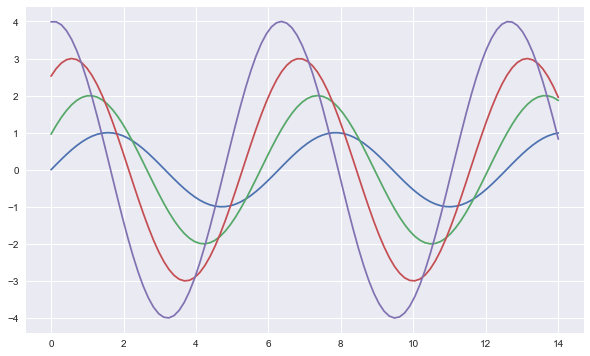

```python
import matplotlib.pyplot as plt
%matplotlib inline

import seaborn as sns

x = np.linspace(0, 14, 100)
y1 = np.sin(x)
y2 = 2*np.sin(x+0.5)
y3 = 3*np.sin(x+1.0)
y4 = 4*np.sin(x+1.5)

plt.figure(figsize=(10,6))
plt.plot(x,y1, x,y2, x,y3, x,y4)
plt.show()
```

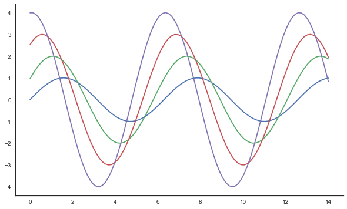

```python
sns.set_style("white")

plt.figure(figsize=(10,6))
plt.plot(x,y1, x,y2, x,y3, x,y4)

sns.despine()

plt.show()
```

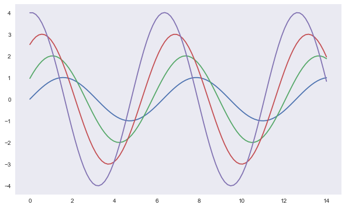

```python
sns.set_style("dark")

plt.figure(figsize=(10,6))
plt.plot(x,y1, x,y2, x,y3, x,y4)
plt.show()
```

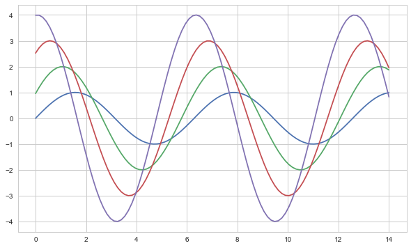

```python
sns.set_style("whitegrid")

plt.figure(figsize=(10,6))
plt.plot(x,y1, x,y2, x,y3, x,y4)
plt.show()
```

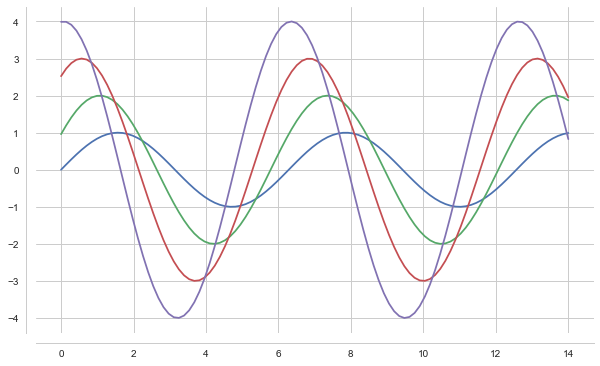

```python
plt.figure(figsize=(10,6))
plt.plot(x,y1, x,y2, x,y3, x,y4)

sns.despine(offset=10)

plt.show()
```

```python
import matplotlib.pyplot as plt
import numpy as np
import seaborn as sns

sns.set_style("whitegrid")
%matplotlib inline
```

```python
tips = sns.load_dataset("tips")
tips.head(5)
```

|  | total_bill | tip | sex | smoker | day | time | size |
| --- | --- | --- | --- | --- | --- | --- | --- |
| 0 | 16.99 | 1.01 | Female | No | Sun | Dinner | 2 |
| 1 | 10.34 | 1.66 | Male | No | Sun | Dinner | 3 |
| 2 | 21.01 | 3.50 | Male | No | Sun | Dinner | 3 |
| 3 | 23.68 | 3.31 | Male | No | Sun | Dinner | 2 |
| 4 | 24.59 | 3.61 | Female | No | Sun | Dinner | 4 |

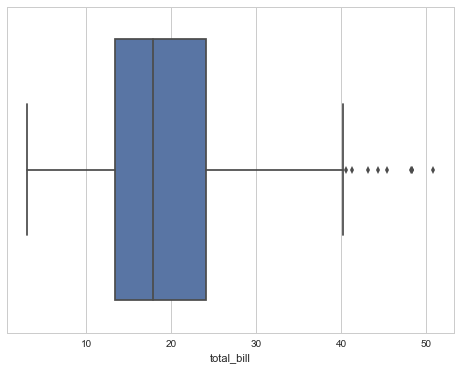

```python
sns.set_style("whitegrid")

plt.figure(figsize=(8,6))
sns.boxplot(x=tips["total_bill"])
plt.show()
```

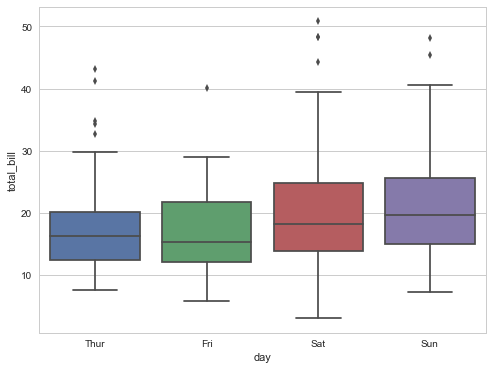

```python
plt.figure(figsize=(8,6))
sns.boxplot(x="day", y="total_bill", data=tips)
plt.show()
```

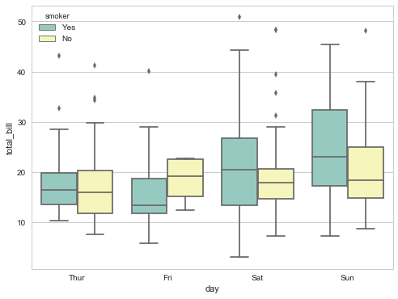

```python
plt.figure(figsize=(8,6))
sns.boxplot(x="day", y="total_bill", hue="smoker", data=tips, palette="Set3")
plt.show()
```

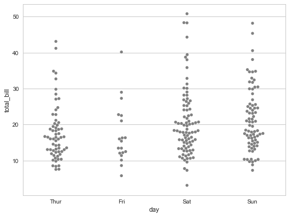

```python
plt.figure(figsize=(8,6))
sns.swarmplot(x="day", y="total_bill", data=tips, color=".5")
plt.show()
```

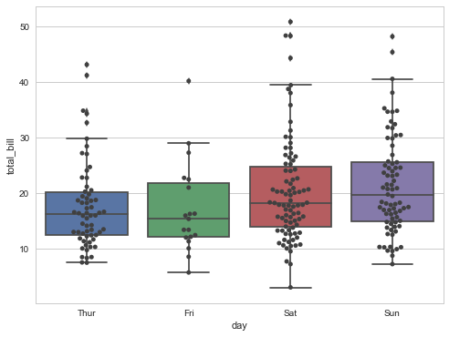

```python
plt.figure(figsize=(8,6))
sns.boxplot(x="day", y="total_bill", data=tips)
sns.swarmplot(x="day", y="total_bill", data=tips, color=".25")
plt.show()
```

```python
import matplotlib.pyplot as plt
import seaborn as sns
%matplotlib inline

tips = sns.load_dataset("tips")
tips.head(5)
```

|  | total_bill | tip | sex | smoker | day | time | size |
| --- | --- | --- | --- | --- | --- | --- | --- |
| 0 | 16.99 | 1.01 | Female | No | Sun | Dinner | 2 |
| 1 | 10.34 | 1.66 | Male | No | Sun | Dinner | 3 |
| 2 | 21.01 | 3.50 | Male | No | Sun | Dinner | 3 |
| 3 | 23.68 | 3.31 | Male | No | Sun | Dinner | 2 |
| 4 | 24.59 | 3.61 | Female | No | Sun | Dinner | 4 |

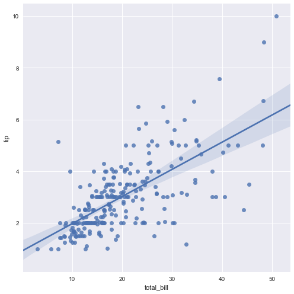

```python
sns.set_style("darkgrid")
sns.lmplot(x="total_bill", y="tip", data=tips, size=7)
plt.show()
```

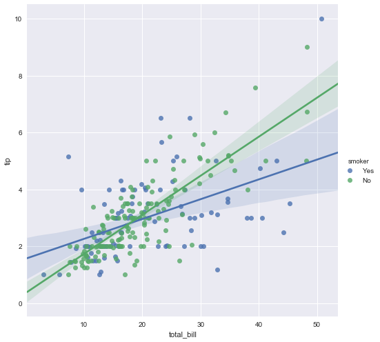

```python
sns.lmplot(x="total_bill", y="tip", hue="smoker", data=tips, size=7)
plt.show()
```

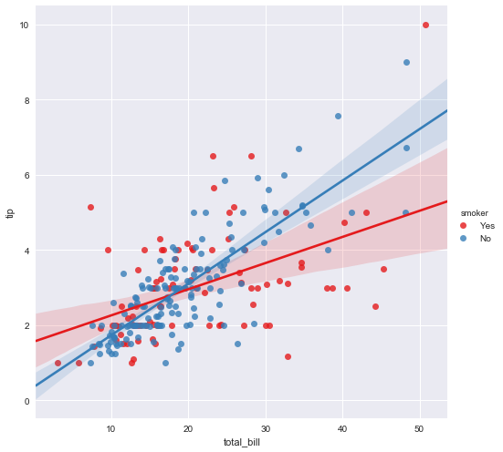

```python
sns.lmplot(x="total_bill", y="tip", hue="smoker", data=tips, palette="Set1", size=7)
plt.show()
```

```python
uniform_data = np.random.rand(10, 12)
uniform_data
```

```
array([[0.91390749, 0.63143953, 0.76625508, 0.75856233, 0.88377659,
        0.2645851 , 0.73197426, 0.06412016, 0.23691681, 0.80589016,
        0.52443503, 0.01496358],
       [0.97585387, 0.30263508, 0.80318235, 0.33666158, 0.16026067,
        0.64499069, 0.25077221, 0.22463871, 0.07326278, 0.86957357,
        0.8515303 , 0.34290453],
       [0.8880865 , 0.66195144, 0.44893245, 0.83475395, 0.76039033,
        0.86762043, 0.39337727, 0.93367561, 0.70160815, 0.54346378,
        0.19059722, 0.8918017 ],
       [0.03759856, 0.25038121, 0.72985546, 0.75133613, 0.0507627 ,
        0.66472472, 0.76460288, 0.31320648, 0.40560935, 0.19090773,
        0.45864177, 0.11241998],
       [0.24494227, 0.54263165, 0.26639153, 0.52723277, 0.90874635,
        0.44753866, 0.80979464, 0.46445129, 0.80570835, 0.51092397,
        0.84539711, 0.20617561],
       [0.60195211, 0.09724605, 0.33396647, 0.39584179, 0.28436181,
        0.41734632, 0.73866313, 0.31885389, 0.86191489, 0.62819352,
        0.09661739, 0.3312701 ],
       [0.21476318, 0.09558067, 0.38946023, 0.52851257, 0.65536847,
        0.3582254 , 0.11261572, 0.78385824, 0.35349296, 0.91219401,
        0.01630392, 0.30596404],
       [0.23072688, 0.32189814, 0.31205276, 0.51355896, 0.30813024,
        0.72030975, 0.11263428, 0.64658323, 0.61250512, 0.8189463 ,
        0.93201665, 0.3619435 ],
       [0.42570326, 0.42038623, 0.18679418, 0.88994936, 0.45988447,
        0.05921313, 0.0224776 , 0.92805434, 0.93476873, 0.42399463,
        0.57877775, 0.36804202],
       [0.67088173, 0.56749587, 0.01420204, 0.2881804 , 0.47206804,
        0.1060772 , 0.62791777, 0.44785905, 0.25370126, 0.96166917,
        0.56340006, 0.60296602]])
```

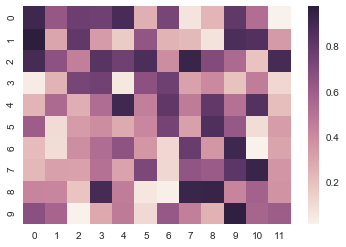

```python
sns.heatmap(uniform_data)
plt.show()
```

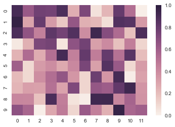

```python
sns.heatmap(uniform_data, vmin=0, vmax=1)
plt.show()
```

```python
flights = sns.load_dataset("flights")
flights.head(5)
```

|  | year | month | passengers |
| --- | --- | --- | --- |
| 0 | 1949 | January | 112 |
| 1 | 1949 | February | 118 |
| 2 | 1949 | March | 132 |
| 3 | 1949 | April | 129 |
| 4 | 1949 | May | 121 |

```python
flights = flights.pivot("month", "year", "passengers")
flights.head(5)
```

| year month | 1949 | 1950 | 1951 | 1952 | 1953 | 1954 | 1955 | 1956 | 1957 | 1958 | 1959 | 1960 |
| --- | --- | --- | --- | --- | --- | --- | --- | --- | --- | --- | --- | --- |
| January | 112 | 115 | 145 | 171 | 196 | 204 | 242 | 284 | 315 | 340 | 360 | 417 |
| February | 118 | 126 | 150 | 180 | 196 | 188 | 233 | 277 | 301 | 318 | 342 | 391 |
| March | 132 | 141 | 178 | 193 | 236 | 235 | 267 | 317 | 356 | 362 | 406 | 419 |
| April | 129 | 135 | 163 | 181 | 235 | 227 | 269 | 313 | 348 | 348 | 396 | 461 |
| May | 121 | 125 | 172 | 183 | 229 | 234 | 270 | 318 | 355 | 363 | 420 | 472 |

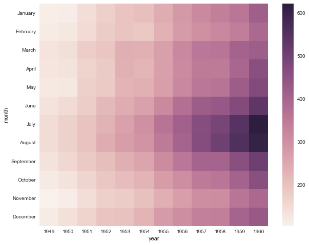

```python
plt.figure(figsize=(10,8))
sns.heatmap(flights)
plt.show()
```

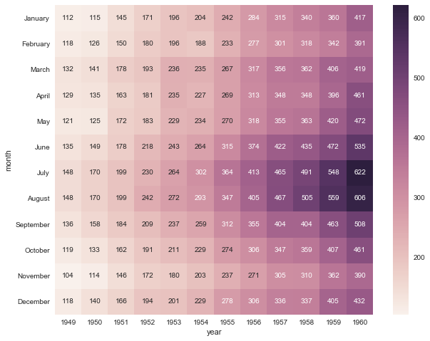

```python
plt.figure(figsize=(10,8))
sns.heatmap(flights, annot=True, fmt="d")
plt.show()
```

```python
sns.set(style="ticks")
iris = sns.load_dataset("iris")
iris.head(10)
```

|  | sepal_length | sepal_width | petal_length | petal_width | species |
| --- | --- | --- | --- | --- | --- |
| 0 | 5.1 | 3.5 | 1.4 | 0.2 | setosa |
| 1 | 4.9 | 3.0 | 1.4 | 0.2 | setosa |
| 2 | 4.7 | 3.2 | 1.3 | 0.2 | setosa |
| 3 | 4.6 | 3.1 | 1.5 | 0.2 | setosa |
| 4 | 5.0 | 3.6 | 1.4 | 0.2 | setosa |
| 5 | 5.4 | 3.9 | 1.7 | 0.4 | setosa |
| 6 | 4.6 | 3.4 | 1.4 | 0.3 | setosa |
| 7 | 5.0 | 3.4 | 1.5 | 0.2 | setosa |
| 8 | 4.4 | 2.9 | 1.4 | 0.2 | setosa |
| 9 | 4.9 | 3.1 | 1.5 | 0.1 | setosa |

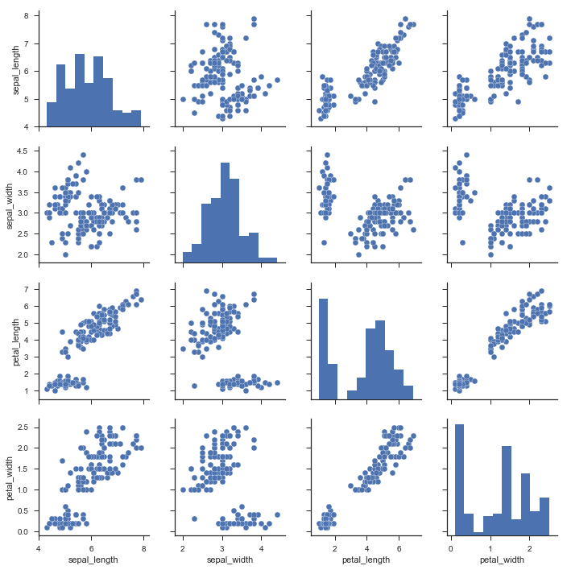

```python
sns.pairplot(iris)
plt.show()
```

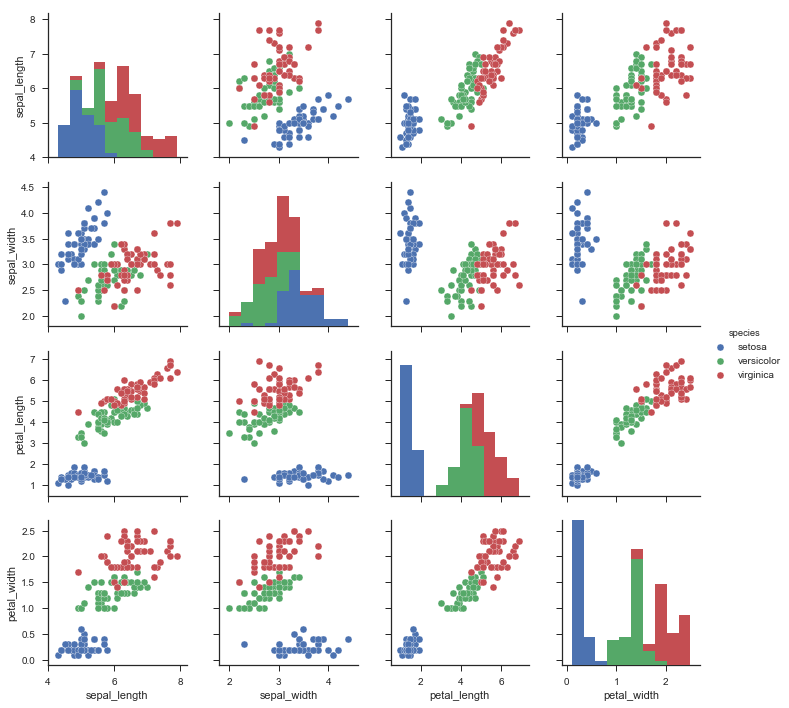

```python
sns.pairplot(iris, hue="species")
plt.show()
```

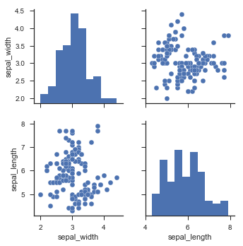

```python
sns.pairplot(iris, vars=["sepal_width", "sepal_length"])
plt.show()
```

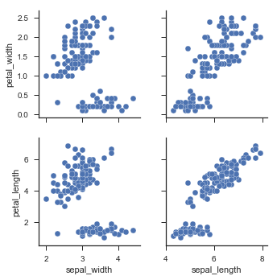

```python
sns.pairplot(iris, x_vars=["sepal_width", "sepal_length"],
             y_vars=["petal_width", "petal_length"])
plt.show()
```

```python
anscombe = sns.load_dataset("anscombe")
anscombe.head(5)
```

|  | dataset | x | y |
| --- | --- | --- | --- |
| 0 | I | 10.0 | 8.04 |
| 1 | I | 8.0 | 6.95 |
| 2 | I | 13.0 | 7.58 |
| 3 | I | 9.0 | 8.81 |
| 4 | I | 11.0 | 8.33 |

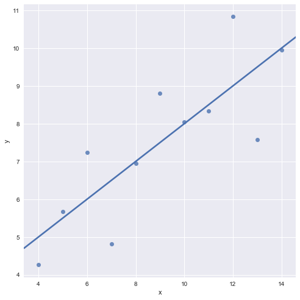

```python
sns.set_style("darkgrid")

sns.lmplot(x="x", y="y", data=anscombe.query("dataset == 'I'"),  ci=None, size=7)
plt.show()
```

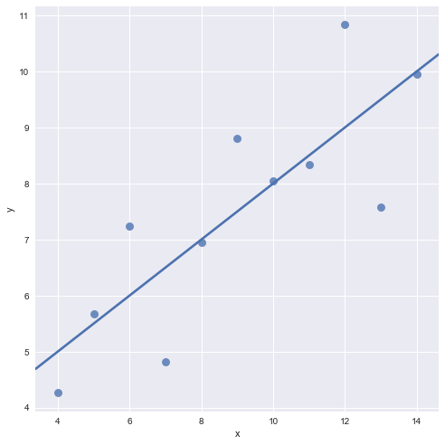

```python
sns.lmplot(x="x", y="y", data=anscombe.query("dataset == 'I'"),
           ci=None, scatter_kws={"s": 80}, size=7)
plt.show()
```

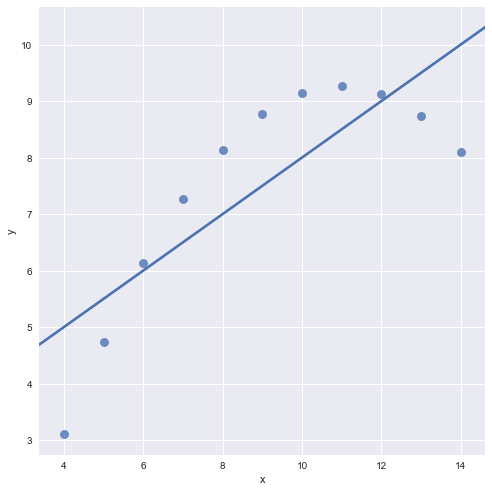

```python
sns.lmplot(x="x", y="y", data=anscombe.query("dataset == 'II'"),
           order=1, ci=None, scatter_kws={"s": 80}, size=7)
plt.show()
```

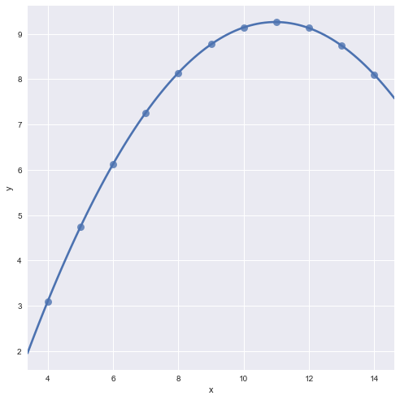

```python
sns.lmplot(x="x", y="y", data=anscombe.query("dataset == 'II'"),
           order=2, ci=None, scatter_kws={"s": 80}, size=7)
plt.show()
```

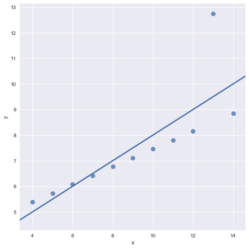

```python
sns.lmplot(x="x", y="y", data=anscombe.query("dataset == 'III'"),
           ci=None, scatter_kws={"s": 80}, size=7)
plt.show()
```

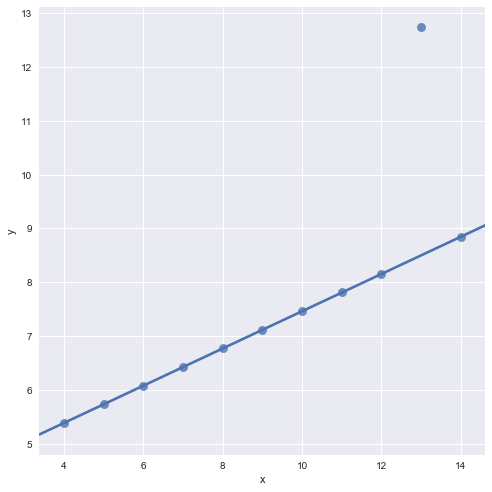

```python
sns.lmplot(x="x", y="y", data=anscombe.query("dataset == 'III'"),
           robust=True, ci=None, scatter_kws={"s": 80}, size=7)
plt.show()
```